# Assignment - Week 2

Reider Ladislau

April 14, 2019

## 1. Loading and preprocessing the data

```r
options(scipen = 3)
setwd("E:/Coursera/Reproducible Research/Week 2/Assignment")
activity <- read.csv(file = "./activity.csv", sep = ",", stringsAsFactors = FALSE, header = TRUE)
# Remove NAs
data_proc <- activity[complete.cases(activity), ]
```

## 2. Create Histogram with the total number of steps taken each day

```r
library(dplyr)
library(magrittr)
steps_per_day <- data_proc %>% dplyr::group_by(date) %>%
        dplyr::summarise(total = sum(steps))
mean_value   <- round(mean(steps_per_day$total, na.rm = TRUE), digits = 1)
median_value <- round(median(steps_per_day$total, na.rm = TRUE), digits = 1)
```

Create the histogram with the number of steps taken each day:

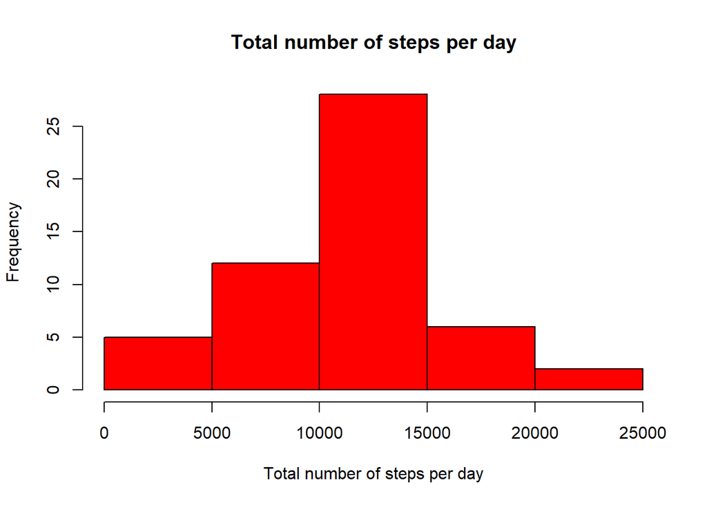

```r
hist(steps_per_day$total, main = "Total number of steps per day",
     xlab = "Total number of steps per day", col = "red")
```

## 3. Add Mean and median number of steps taken each day

Mean of total number of steps per day is 10766.2, median is 10765.

## 4. Add Time series plot of the average number of steps taken

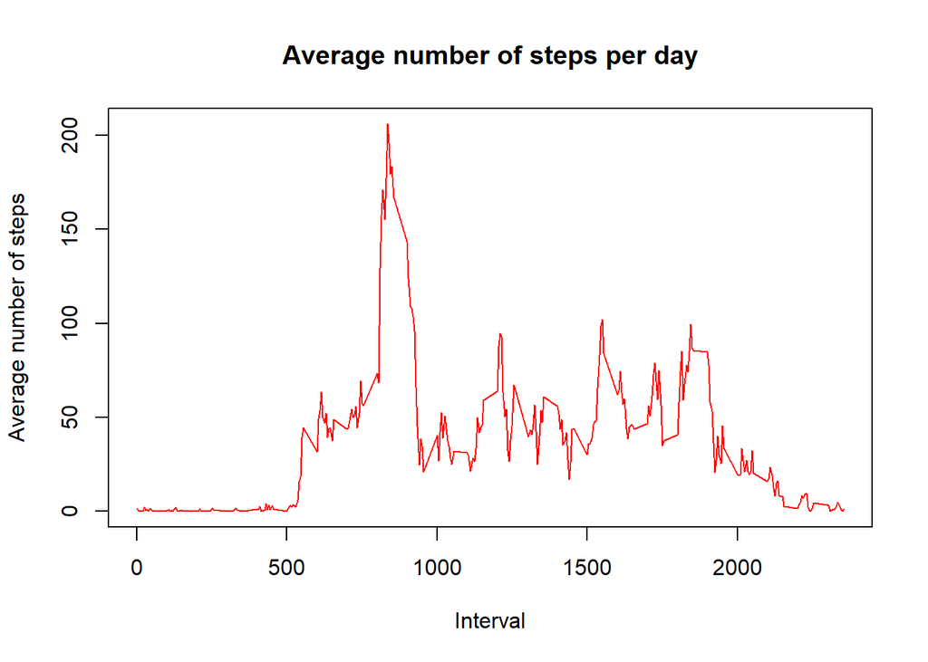

```r
avg_steps <- aggregate(steps ~ interval, data_proc, mean)

plot(as.numeric(avg_steps$interval), avg_steps$steps, type = 'l',
     main = "Average number of steps per day", xlab = "Interval",
     ylab = "Average number of steps", col = "red")
```

## 5. Add The 5-minute interval that, on average, contains the maximum number of steps

```r
# Row which has the highest average steps
row_nr <- which.max(avg_steps$steps)

# Identify interval and the average steps for this interval
max_interval <- avg_steps[row_nr, ]$interval
max_steps <- round(avg_steps[row_nr, ]$steps, digits = 1)
```

The 5-min interval that, on average contains the maximum number of steps is 835 and the number of steps for this interval is 206.2

## 6. Add code to describe and show a strategy for imputing missing data

```r
# Number of rows with missing data
sum(is.na(activity))
```

```
## [1] 2304
```

```r
# The adopted strategy is to replace the missing values with the average steps in that interval across all the days
for (i in 1:nrow(activity)) {
    if(is.na(activity$steps[i]))
        {
        value <- avg_steps$steps[which(avg_steps$interval==activity$interval[i])]
        activity$steps[i] <- value
        }
}

steps_per_day_imputed <- aggregate(steps ~ date, activity, sum)
```

## 7. Create histogram of the total number of steps taken each day after missing values are imputed

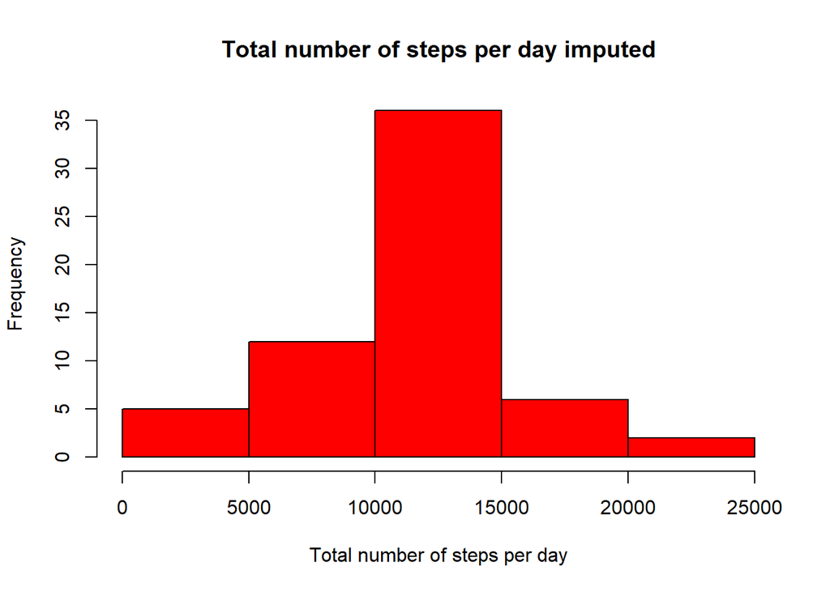

```r
# Create histogram plot
hist(steps_per_day_imputed$steps, main = "Total number of steps per day imputed", xlab = "Total number of steps per day", col = "red")
```

Compare the mean and median with and without NAs

```r
# get average and median of imputed data
mean_imputed   <- round(mean(steps_per_day_imputed$steps), digits = 1)
median_imputed <- round(median(steps_per_day_imputed$steps), digits = 1)
```

The mean value without imputed data is 10766.2 The mean value with imputed data is 10766.2 The median value without imputed data is 10765 The median value with imputed data is 10766.2 As a conseuence the mean values do not change, but there is a very slight difference in the meadian values.

## 8. Panel plot comparing the average number of steps taken per 5-minute interval across weekdays and weekends

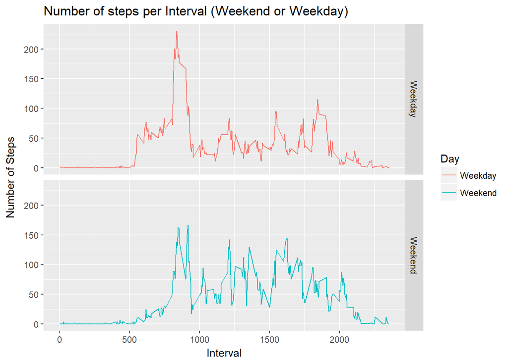

```r
library(ggplot2)
# Create extra column with Weekday or Weekend
activity$Day <- weekdays(as.Date(activity$date))
activity$Day[activity$Day  %in% c('Saturday','Sunday') ] <- "Weekend"
activity$Day[activity$Day != "Weekend"] <- "Weekday"

# Convert type from character to factor
activity$Day <- as.factor(activity$Day)

# Calculate average steps by interval
avg_steps_per_day_imputed <- aggregate(steps ~ interval + Day, activity, mean)

# Create plot
ggplot2::ggplot(avg_steps_per_day_imputed, aes(interval, steps)) +
    geom_line(stat = "identity", aes(colour = Day)) +
    theme_gray() +
    facet_grid(Day ~ ., scales = "fixed", space = "fixed") +
    labs(x = "Interval", y = expression("Number of Steps")) +
    ggtitle("Number of steps per Interval (Weekend or Weekday)")
```